# Report

Mason Wong, Eva Yin, Zhuolin Jiang, Matthew Shu

14/05/2022

```r
library(GGally)
library(tidyverse)
library(visdat)
library(MASS) # for the forward, backward and bidirectional search
```

## Data Description & Visualisation

To Do:

- Summary Statistics
- Check if some relationships are curvilinear
- Correlation Matrix <- discuss multicollinearity < `qtlcharts::iplotCorr(df)` for innovation, `ggally` for all pairs
- Correlation should also give us hints as to what interaction effects to fit
- Missing Data / Strange Data <- relevant to model building <- vismiss for innovation
- Some background / literature
- Literature guidance on important variables for model from domain knowledge

https://stats.stackexchange.com/questions/395562/interpreting-interaction-term-on-highly-correlated-variables?rq=1

https://www.theanalysisfactor.com/regression-modelshow-do-you-know-you-need-a-polynomial/

```r
df = read.csv("../data/seatbelt_group_14.csv", stringsAsFactors = TRUE)
df %>% head(. , 3)
```

```
##   state year miles fatalities seatbelt speed65 speed70 drinkage alcohol income
## 1    GA 1989 75705 0.02155736    0.388     yes      no      yes      no  16466
## 2    DC 1990  3407 0.01408864    0.490     yes      no      yes      no  25646
## 3    GA 1995 85384 0.01742715    0.507     yes     yes      yes      no  21696
##        age   enforce
## 1 33.58587 secondary
## 2 36.91365 secondary
## 3 34.41508 secondary
```

- It seems like data is in the range of 1983 to 1997
- There is a lot of missing data surrounding the rate of seatbelt usage in each state, in each year.
- There is no missing data elsewhere.
- Potential solution might be to build a model without the seatbelt & w/ seatbelt to avoid dropping all the rows

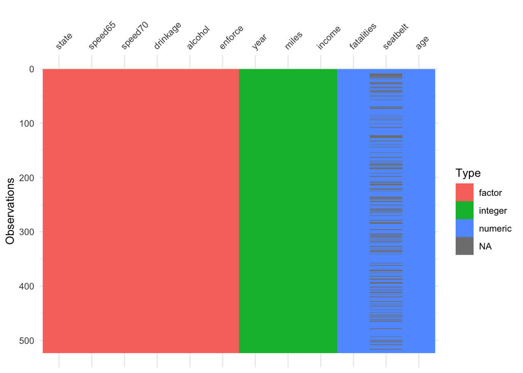

```r
# Get an initial feel of our data
vis_dat(df)
```

```r
str(df)
```

```
## 'data.frame':    523 obs. of  12 variables:
##  $ state     : Factor w/ 35 levels "AK","AL","AR",..: 11 8 11 6 11 15 15 24 1 33 ...
##  $ year      : int  1989 1990 1995 1993 1991 1985 1995 1986 1989 1985 ...
##  $ miles     : int  75705 3407 85384 32718 73005 70844 94189 33806 3887 13269 ...
##  $ fatalities: num  0.0216 0.0141 0.0174 0.0171 0.019 ...
##  $ seatbelt  : num  0.388 0.49 0.507 0.53 0.456 ...
##  $ speed65   : Factor w/ 2 levels "no","yes": 2 2 2 2 2 1 2 1 1 1 ...
##  $ speed70   : Factor w/ 2 levels "no","yes": 1 1 2 1 1 1 1 1 1 1 ...
##  $ drinkage  : Factor w/ 2 levels "no","yes": 2 2 2 2 2 2 2 2 2 2 ...
##  $ alcohol   : Factor w/ 2 levels "no","yes": 1 1 1 1 1 1 1 1 1 1 ...
##  $ income    : int  16466 25646 21696 22117 17930 15322 25135 15526 19970 11592 ...
##  $ age       : num  33.6 36.9 34.4 34.6 34 ...
##  $ enforce   : Factor w/ 3 levels "no","primary",..: 3 3 3 3 3 1 3 3 1 1 ...
```

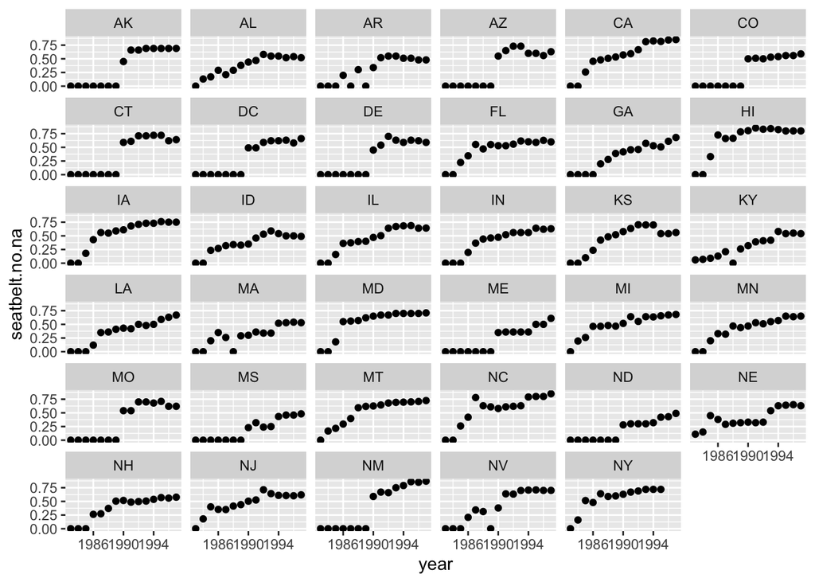

```r
# a temporary data frame, made to observe the NA's specifically across each state at each year
temp = df %>%
  dplyr::select(state, year, seatbelt) %>%
  group_by(year) %>%
  arrange(year) %>%
  arrange(state)

# for the NA's replace them with zeroes
temp = temp %>% mutate(seatbelt.no.na = case_when(is.na(seatbelt) ~ 0, TRUE ~ seatbelt))

# observe the plot of NA's by year and state
temp %>% ggplot(. , aes(x = year, y = seatbelt.no.na)) +
  geom_point() +
  facet_wrap(~state)
```

High collinearity

- `Income` and `Year` (Positive)
- `Income` and `Fatalities` (Negative)
- `Fatalities` and `Year` (Negative)
- `Speed65`, `Speed75` more prevalent in later years

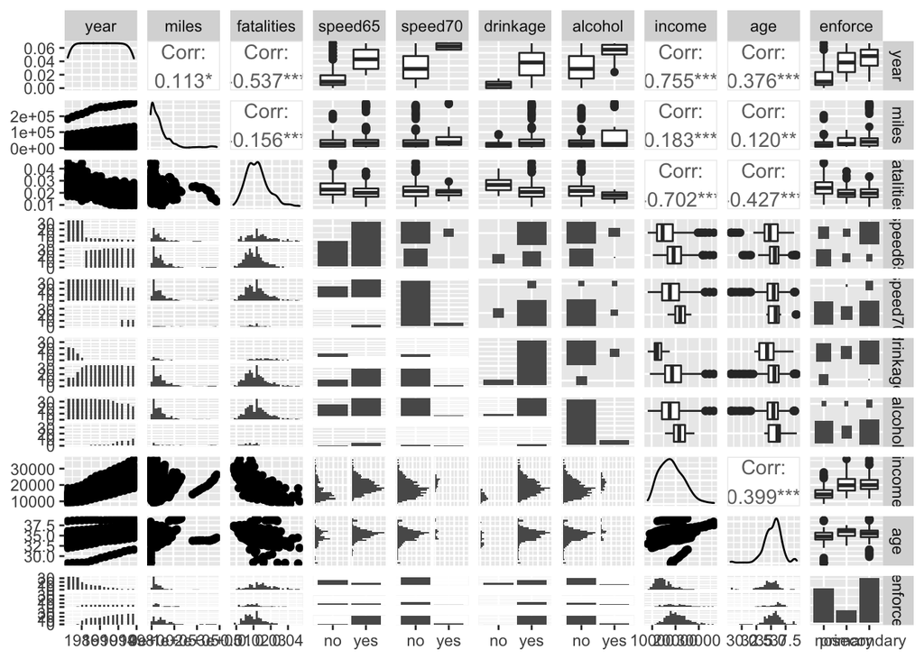

```r
df %>%
  dplyr::select(-seatbelt, -state) %>%
  ggpairs()
```

```r
#ggpairs(df)
```

## Coarse grain search with forward, backward and bidirectional

We firstly get rid of the variables to do with state and seatbelt

```r
# take away state and seatbelt as variables and create the full and null model
df.no_ss = df %>% dplyr::select(-state, -seatbelt)
n = nrow(df.no_ss)
full_model = lm(fatalities ~ . , data = df.no_ss)
null_model = lm(fatalities ~ 1 , data = df.no_ss)
```

we perform a forward search with the aic and bic criterion

```r
# forward model with aic criterion
forward_model_aic = stepAIC(null_model,
                        scope = list(upper = formula(full_model),
                                     lower = formula(null_model)),
                        direction = 'forward',
                        k = 2)
```

```
## Start:  AIC=-5285.47
## fatalities ~ 1
##
##            Df Sum of Sq      RSS     AIC
## + income    1 0.0104969 0.010776 -5639.2
## + year      1 0.0061293 0.015144 -5461.2
## + age       1 0.0038737 0.017399 -5388.6
## + enforce   2 0.0024520 0.018821 -5345.5
## + drinkage  1 0.0015213 0.019752 -5322.3
## + speed65   1 0.0013593 0.019914 -5318.0
## + alcohol   1 0.0008239 0.020449 -5304.1
## + miles     1 0.0005148 0.020758 -5296.3
## <none>                  0.021273 -5285.5
## + speed70   1 0.0000550 0.021218 -5284.8
##
## Step:  AIC=-5639.16
## fatalities ~ income
##
##            Df  Sum of Sq      RSS     AIC
## + age       1 0.00054294 0.010233 -5664.2
## + speed70   1 0.00013515 0.010641 -5643.8
## + alcohol   1 0.00007935 0.010697 -5641.0
## <none>                   0.010776 -5639.2
## + speed65   1 0.00003164 0.010745 -5638.7
## + miles     1 0.00001599 0.010760 -5637.9
## + enforce   2 0.00005241 0.010724 -5637.7
## + drinkage  1 0.00000331 0.010773 -5637.3
## + year      1 0.00000202 0.010774 -5637.3
##
## Step:  AIC=-5664.2
## fatalities ~ income + age
##
##            Df  Sum of Sq      RSS     AIC
## + speed70   1 1.4248e-04 0.010091 -5669.5
## + alcohol   1 5.4286e-05 0.010179 -5665.0
## + enforce   2 8.0347e-05 0.010153 -5664.3
## <none>                   0.010233 -5664.2
## + miles     1 7.7680e-06 0.010226 -5662.6
## + drinkage  1 7.3510e-06 0.010226 -5662.6
## + speed65   1 7.3460e-06 0.010226 -5662.6
```

[output cut: 9 more lines]

```
## + speed65   1 2.1749e-05 0.0100692 -5668.7
## + miles     1 1.7425e-05 0.0100735 -5668.4
## + year      1 1.0326e-05 0.0100806 -5668.1
## + drinkage  1 5.9450e-06 0.0100850 -5667.8
##
## Step:  AIC=-5675.23
## fatalities ~ income + age + speed70 + alcohol
##
##            Df  Sum of Sq       RSS     AIC
## <none>                   0.0099434 -5675.2
## + enforce   2 6.6554e-05 0.0098768 -5674.7
## + speed65   1 1.0172e-05 0.0099332 -5673.8
## + drinkage  1 7.6060e-06 0.0099358 -5673.6
## + miles     1 2.1820e-06 0.0099412 -5673.3
## + year      1 1.0140e-06 0.0099424 -5673.3
```

```r
# forward model with bic criterion
forward_model_bic = stepAIC(null_model,
                        scope = list(upper = formula(full_model),
                                     lower = formula(null_model)),
                        direction = 'forward',
                        k = log(n))
```

```
## Start:  AIC=-5281.21
## fatalities ~ 1
##
##            Df Sum of Sq      RSS     AIC
## + income    1 0.0104969 0.010776 -5630.6
## + year      1 0.0061293 0.015144 -5452.7
## + age       1 0.0038737 0.017399 -5380.1
## + enforce   2 0.0024520 0.018821 -5332.7
## + drinkage  1 0.0015213 0.019752 -5313.8
## + speed65   1 0.0013593 0.019914 -5309.5
## + alcohol   1 0.0008239 0.020449 -5295.6
## + miles     1 0.0005148 0.020758 -5287.8
## <none>                  0.021273 -5281.2
## + speed70   1 0.0000550 0.021218 -5276.3
##
## Step:  AIC=-5630.64
## fatalities ~ income
##
##            Df  Sum of Sq      RSS     AIC
## + age       1 0.00054294 0.010233 -5651.4
## + speed70   1 0.00013515 0.010641 -5631.0
## <none>                   0.010776 -5630.6
## + alcohol   1 0.00007935 0.010697 -5628.2
## + speed65   1 0.00003164 0.010745 -5625.9
## + miles     1 0.00001599 0.010760 -5625.2
## + drinkage  1 0.00000331 0.010773 -5624.5
## + year      1 0.00000202 0.010774 -5624.5
## + enforce   2 0.00005241 0.010724 -5620.7
##
## Step:  AIC=-5651.42
## fatalities ~ income + age
##
##            Df  Sum of Sq      RSS     AIC
## + speed70   1 1.4248e-04 0.010091 -5652.5
## <none>                   0.010233 -5651.4
## + alcohol   1 5.4286e-05 0.010179 -5647.9
## + miles     1 7.7680e-06 0.010226 -5645.6
## + drinkage  1 7.3510e-06 0.010226 -5645.5
## + speed65   1 7.3460e-06 0.010226 -5645.5
## + year      1 2.2650e-06 0.010231 -5645.3
```

[output cut: 9 more lines]

```
## + miles     1 1.7425e-05 0.0100735 -5647.1
## + year      1 1.0326e-05 0.0100806 -5646.8
## + drinkage  1 5.9450e-06 0.0100850 -5646.5
## + enforce   2 6.7875e-05 0.0100231 -5643.5
##
## Step:  AIC=-5653.94
## fatalities ~ income + age + speed70 + alcohol
##
##            Df  Sum of Sq       RSS     AIC
## <none>                   0.0099434 -5653.9
## + speed65   1 1.0172e-05 0.0099332 -5648.2
## + drinkage  1 7.6060e-06 0.0099358 -5648.1
## + miles     1 2.1820e-06 0.0099412 -5647.8
## + year      1 1.0140e-06 0.0099424 -5647.7
## + enforce   2 6.6554e-05 0.0098768 -5644.9
```

$$fatalities \thicksim income + age + speed70 + alcohol$$

We perform a backward search

```r
# backward model with AIC criterion
backward_model_AIC = stepAIC(full_model,
                        scope = list(upper = formula(full_model),
                                     lower = formula(null_model)),
                        direction = 'backward',
                        k = 2)
```

```
## Start:  AIC=-5668.59
## fatalities ~ year + miles + speed65 + speed70 + drinkage + alcohol +
##     income + age + enforce
##
##            Df  Sum of Sq       RSS     AIC
## - year      1 0.00000196 0.0098441 -5670.5
## - drinkage  1 0.00000840 0.0098506 -5670.1
## - miles     1 0.00000879 0.0098510 -5670.1
## - speed65   1 0.00001333 0.0098555 -5669.9
## - enforce   2 0.00006858 0.0099108 -5669.0
## <none>                   0.0098422 -5668.6
## - alcohol   1 0.00008338 0.0099256 -5666.2
## - speed70   1 0.00021636 0.0100585 -5659.2
## - age       1 0.00048800 0.0103302 -5645.3
## - income    1 0.00288565 0.0127278 -5536.1
##
## Step:  AIC=-5670.48
## fatalities ~ miles + speed65 + speed70 + drinkage + alcohol +
##     income + age + enforce
##
##            Df Sum of Sq       RSS     AIC
## - miles     1 0.0000074 0.0098516 -5672.1
## - drinkage  1 0.0000080 0.0098521 -5672.1
## - speed65   1 0.0000276 0.0098717 -5671.0
## - enforce   2 0.0000673 0.0099114 -5670.9
## <none>                  0.0098441 -5670.5
## - alcohol   1 0.0000932 0.0099373 -5667.6
## - speed70   1 0.0002259 0.0100700 -5660.6
## - age       1 0.0004933 0.0103374 -5646.9
## - income    1 0.0056178 0.0154620 -5436.3
##
## Step:  AIC=-5672.09
## fatalities ~ speed65 + speed70 + drinkage + alcohol + income +
##     age + enforce
##
##            Df Sum of Sq       RSS     AIC
## - drinkage  1 0.0000074 0.0098590 -5673.7
## - speed65   1 0.0000238 0.0098754 -5672.8
## - enforce   2 0.0000630 0.0099146 -5672.8
## <none>                  0.0098516 -5672.1
```

[output cut: 22 more lines]

```
## <none>                 0.0098768 -5674.7
## - alcohol  1 0.0001462 0.0100231 -5669.1
## - speed70  1 0.0002239 0.0101007 -5665.0
## - age      1 0.0005373 0.0104141 -5649.0
## - income   1 0.0057687 0.0156455 -5436.2
##
## Step:  AIC=-5675.23
## fatalities ~ speed70 + alcohol + income + age
##
##           Df Sum of Sq       RSS     AIC
## <none>                 0.0099434 -5675.2
## - alcohol  1 0.0001475 0.0100909 -5669.5
## - speed70  1 0.0002357 0.0101791 -5665.0
## - age      1 0.0005109 0.0104543 -5651.0
## - income   1 0.0070130 0.0169564 -5398.1
```

```r
# backward model with BIC criterion
backward_model_BIC = stepAIC(full_model,
                        scope = list(upper = formula(full_model),
                                     lower = formula(null_model)),
                        direction = 'backward',
                        k = log(n))
```

```
## Start:  AIC=-5621.73
## fatalities ~ year + miles + speed65 + speed70 + drinkage + alcohol +
##     income + age + enforce
##
##            Df  Sum of Sq       RSS     AIC
## - enforce   2 0.00006858 0.0099108 -5630.6
## - year      1 0.00000196 0.0098441 -5627.9
## - drinkage  1 0.00000840 0.0098506 -5627.5
## - miles     1 0.00000879 0.0098510 -5627.5
## - speed65   1 0.00001333 0.0098555 -5627.3
## - alcohol   1 0.00008338 0.0099256 -5623.6
## <none>                   0.0098422 -5621.7
## - speed70   1 0.00021636 0.0100585 -5616.6
## - age       1 0.00048800 0.0103302 -5602.7
## - income    1 0.00288565 0.0127278 -5493.5
##
## Step:  AIC=-5630.62
## fatalities ~ year + miles + speed65 + speed70 + drinkage + alcohol +
##     income + age
##
##            Df  Sum of Sq       RSS     AIC
## - year      1 0.00000064 0.0099114 -5636.8
## - miles     1 0.00000262 0.0099134 -5636.7
## - speed65   1 0.00001737 0.0099281 -5636.0
## - drinkage  1 0.00001849 0.0099292 -5635.9
## - alcohol   1 0.00011698 0.0100277 -5630.7
## <none>                   0.0099108 -5630.6
## - speed70   1 0.00021451 0.0101253 -5625.7
## - age       1 0.00048124 0.0103920 -5612.1
## - income    1 0.00287912 0.0127899 -5503.5
##
## Step:  AIC=-5636.84
## fatalities ~ miles + speed65 + speed70 + drinkage + alcohol +
##     income + age
##
##            Df Sum of Sq       RSS     AIC
## - miles     1 0.0000032 0.0099146 -5642.9
## - drinkage  1 0.0000194 0.0099308 -5642.1
## - speed65   1 0.0000219 0.0099333 -5641.9
## - alcohol   1 0.0001176 0.0100290 -5636.9
```

[output cut: 23 more lines]

```
## <none>                 0.0099332 -5648.2
## - alcohol  1 0.0001359 0.0100692 -5647.4
## - speed70  1 0.0002437 0.0101769 -5641.8
## - age      1 0.0004870 0.0104202 -5629.4
## - income   1 0.0066124 0.0165456 -5387.6
##
## Step:  AIC=-5653.94
## fatalities ~ speed70 + alcohol + income + age
##
##           Df Sum of Sq       RSS     AIC
## <none>                 0.0099434 -5653.9
## - alcohol  1 0.0001475 0.0100909 -5652.5
## - speed70  1 0.0002357 0.0101791 -5647.9
## - age      1 0.0005109 0.0104543 -5634.0
## - income   1 0.0070130 0.0169564 -5381.1
```

$$fatalities \thicksim speed70 + alcohol + income + age$$

We perform a bidirectional search

```r
# bidirectional model with AIC criterion
bidirectional_model_AIC = stepAIC(full_model,
                        scope = list(upper = formula(full_model),
                                     lower = formula(null_model)),
                        direction = 'both',
                        k = 2)
```

```
## Start:  AIC=-5668.59
## fatalities ~ year + miles + speed65 + speed70 + drinkage + alcohol +
##     income + age + enforce
##
##            Df  Sum of Sq       RSS     AIC
## - year      1 0.00000196 0.0098441 -5670.5
## - drinkage  1 0.00000840 0.0098506 -5670.1
## - miles     1 0.00000879 0.0098510 -5670.1
## - speed65   1 0.00001333 0.0098555 -5669.9
## - enforce   2 0.00006858 0.0099108 -5669.0
## <none>                   0.0098422 -5668.6
## - alcohol   1 0.00008338 0.0099256 -5666.2
## - speed70   1 0.00021636 0.0100585 -5659.2
## - age       1 0.00048800 0.0103302 -5645.3
## - income    1 0.00288565 0.0127278 -5536.1
##
## Step:  AIC=-5670.48
## fatalities ~ miles + speed65 + speed70 + drinkage + alcohol +
##     income + age + enforce
##
##            Df Sum of Sq       RSS     AIC
## - miles     1 0.0000074 0.0098516 -5672.1
## - drinkage  1 0.0000080 0.0098521 -5672.1
## - speed65   1 0.0000276 0.0098717 -5671.0
## - enforce   2 0.0000673 0.0099114 -5670.9
## <none>                  0.0098441 -5670.5
## + year      1 0.0000020 0.0098422 -5668.6
## - alcohol   1 0.0000932 0.0099373 -5667.6
## - speed70   1 0.0002259 0.0100700 -5660.6
## - age       1 0.0004933 0.0103374 -5646.9
## - income    1 0.0056178 0.0154620 -5436.3
##
## Step:  AIC=-5672.09
## fatalities ~ speed65 + speed70 + drinkage + alcohol + income +
##     age + enforce
##
##            Df Sum of Sq       RSS     AIC
## - drinkage  1 0.0000074 0.0098590 -5673.7
## - speed65   1 0.0000238 0.0098754 -5672.8
## - enforce   2 0.0000630 0.0099146 -5672.8
```

[output cut: 37 more lines]

```
##
## Step:  AIC=-5675.23
## fatalities ~ speed70 + alcohol + income + age
##
##            Df Sum of Sq       RSS     AIC
## <none>                  0.0099434 -5675.2
## + enforce   2 0.0000666 0.0098768 -5674.7
## + speed65   1 0.0000102 0.0099332 -5673.8
## + drinkage  1 0.0000076 0.0099358 -5673.6
## + miles     1 0.0000022 0.0099412 -5673.3
## + year      1 0.0000010 0.0099424 -5673.3
## - alcohol   1 0.0001475 0.0100909 -5669.5
## - speed70   1 0.0002357 0.0101791 -5665.0
## - age       1 0.0005109 0.0104543 -5651.0
## - income    1 0.0070130 0.0169564 -5398.1
```

```r
# bidirectional model with BIC criterion
bidirectional_model_BIC = stepAIC(full_model,
                        scope = list(upper = formula(full_model),
                                     lower = formula(null_model)),
                        direction = 'both',
                        k = log(n))
```

```
## Start:  AIC=-5621.73
## fatalities ~ year + miles + speed65 + speed70 + drinkage + alcohol +
##     income + age + enforce
##
##            Df  Sum of Sq       RSS     AIC
## - enforce   2 0.00006858 0.0099108 -5630.6
## - year      1 0.00000196 0.0098441 -5627.9
## - drinkage  1 0.00000840 0.0098506 -5627.5
## - miles     1 0.00000879 0.0098510 -5627.5
## - speed65   1 0.00001333 0.0098555 -5627.3
## - alcohol   1 0.00008338 0.0099256 -5623.6
## <none>                   0.0098422 -5621.7
## - speed70   1 0.00021636 0.0100585 -5616.6
## - age       1 0.00048800 0.0103302 -5602.7
## - income    1 0.00288565 0.0127278 -5493.5
##
## Step:  AIC=-5630.62
## fatalities ~ year + miles + speed65 + speed70 + drinkage + alcohol +
##     income + age
##
##            Df  Sum of Sq       RSS     AIC
## - year      1 0.00000064 0.0099114 -5636.8
## - miles     1 0.00000262 0.0099134 -5636.7
## - speed65   1 0.00001737 0.0099281 -5636.0
## - drinkage  1 0.00001849 0.0099292 -5635.9
## - alcohol   1 0.00011698 0.0100277 -5630.7
## <none>                   0.0099108 -5630.6
## - speed70   1 0.00021451 0.0101253 -5625.7
## + enforce   2 0.00006858 0.0098422 -5621.7
## - age       1 0.00048124 0.0103920 -5612.1
## - income    1 0.00287912 0.0127899 -5503.5
##
## Step:  AIC=-5636.84
## fatalities ~ miles + speed65 + speed70 + drinkage + alcohol +
##     income + age
##
##            Df Sum of Sq       RSS     AIC
## - miles     1 0.0000032 0.0099146 -5642.9
## - drinkage  1 0.0000194 0.0099308 -5642.1
## - speed65   1 0.0000219 0.0099333 -5641.9
```

[output cut: 38 more lines]

```
##
## Step:  AIC=-5653.94
## fatalities ~ speed70 + alcohol + income + age
##
##            Df Sum of Sq       RSS     AIC
## <none>                  0.0099434 -5653.9
## - alcohol   1 0.0001475 0.0100909 -5652.5
## + speed65   1 0.0000102 0.0099332 -5648.2
## + drinkage  1 0.0000076 0.0099358 -5648.1
## - speed70   1 0.0002357 0.0101791 -5647.9
## + miles     1 0.0000022 0.0099412 -5647.8
## + year      1 0.0000010 0.0099424 -5647.7
## + enforce   2 0.0000666 0.0098768 -5644.9
## - age       1 0.0005109 0.0104543 -5634.0
## - income    1 0.0070130 0.0169564 -5381.1
```

We see that with all three methods we converge onto the model

$$fatalities \thicksim speed70 + alcohol + income + age$$

If we consider a polynomial term we seem to get substationally better:

```r
quadratic_model = lm(fatalities ~ speed70 + alcohol + age + income + I(income^2), data = df.no_ss)
summary(quadratic_model)
```

```
##
## Call:
## lm(formula = fatalities ~ speed70 + alcohol + age + income +
##     I(income^2), data = df.no_ss)
##
## Residuals:
##        Min         1Q     Median         3Q        Max
## -0.0120402 -0.0024401 -0.0002487  0.0019764  0.0187371
##
## Coefficients:
##               Estimate Std. Error t value Pr(>|t|)
## (Intercept)  7.435e-02  4.691e-03  15.850  < 2e-16 ***
## speed70yes   3.354e-03  7.901e-04   4.245 2.59e-05 ***
## alcoholyes  -1.503e-03  7.037e-04  -2.135   0.0332 *
## age         -6.931e-04  1.255e-04  -5.522 5.33e-08 ***
## income      -2.258e-06  2.225e-07 -10.148  < 2e-16 ***
## I(income^2)  3.635e-11  5.485e-12   6.627 8.62e-11 ***
## ---
## Signif. codes:  0 '***' 0.001 '**' 0.01 '*' 0.05 '.' 0.1 ' ' 1
##
## Residual standard error: 0.00421 on 517 degrees of freedom
## Multiple R-squared:  0.5692, Adjusted R-squared:  0.565
## F-statistic: 136.6 on 5 and 517 DF,  p-value: < 2.2e-16
```

$$fatalities \thicksim speed70 + alcohol + age + income +
I(income^2)$$

The final thing we probably want to consider is decreasing the categorical variables:

1. take away speed70

```r
no_speed70_model = lm(fatalities ~ alcohol + age + income + I(income^2), data = df.no_ss)
summary(no_speed70_model)
```

```
##
## Call:
## lm(formula = fatalities ~ alcohol + age + income + I(income^2),
##     data = df.no_ss)
##
## Residuals:
##        Min         1Q     Median         3Q        Max
## -0.0120621 -0.0025910 -0.0003882  0.0020307  0.0185224
##
## Coefficients:
##               Estimate Std. Error t value Pr(>|t|)
## (Intercept)  7.346e-02  4.763e-03  15.425  < 2e-16 ***
## alcoholyes  -5.286e-04  6.761e-04  -0.782    0.435
## age         -6.973e-04  1.276e-04  -5.466 7.18e-08 ***
## income      -2.152e-06  2.247e-07  -9.575  < 2e-16 ***
## I(income^2)  3.419e-11  5.551e-12   6.160 1.46e-09 ***
## ---
## Signif. codes:  0 '***' 0.001 '**' 0.01 '*' 0.05 '.' 0.1 ' ' 1
##
## Residual standard error: 0.004279 on 518 degrees of freedom
## Multiple R-squared:  0.5542, Adjusted R-squared:  0.5507
## F-statistic:   161 on 4 and 518 DF,  p-value: < 2.2e-16
```

2. take away alcohol

```r
no_alcohol_model = lm(fatalities ~ speed70 + age + income + I(income^2), data = df.no_ss)
summary(no_alcohol_model)
```

```
##
## Call:
## lm(formula = fatalities ~ speed70 + age + income + I(income^2),
##     data = df.no_ss)
##
## Residuals:
##        Min         1Q     Median         3Q        Max
## -0.0120003 -0.0025640 -0.0003436  0.0019058  0.0187342
##
## Coefficients:
##               Estimate Std. Error t value Pr(>|t|)
## (Intercept)  7.554e-02  4.673e-03  16.163  < 2e-16 ***
## speed70yes   2.804e-03  7.495e-04   3.742 0.000203 ***
## age         -7.115e-04  1.257e-04  -5.661 2.49e-08 ***
## income      -2.319e-06  2.215e-07 -10.469  < 2e-16 ***
## I(income^2)  3.765e-11  5.470e-12   6.882 1.71e-11 ***
## ---
## Signif. codes:  0 '***' 0.001 '**' 0.01 '*' 0.05 '.' 0.1 ' ' 1
##
## Residual standard error: 0.004225 on 518 degrees of freedom
## Multiple R-squared:  0.5654, Adjusted R-squared:  0.562
## F-statistic: 168.5 on 4 and 518 DF,  p-value: < 2.2e-16
```

3. take away both

```r
continous_model = lm(fatalities ~ age + income + I(income^2), data = df.no_ss)
summary(continous_model)
```

```
##
## Call:
## lm(formula = fatalities ~ age + income + I(income^2), data = df.no_ss)
##
## Residuals:
##        Min         1Q     Median         3Q        Max
## -0.0120450 -0.0026337 -0.0003709  0.0020028  0.0185351
##
## Coefficients:
##               Estimate Std. Error t value Pr(>|t|)
## (Intercept)  7.399e-02  4.713e-03  15.699  < 2e-16 ***
## age         -7.042e-04  1.272e-04  -5.536 4.93e-08 ***
## income      -2.182e-06  2.212e-07  -9.867  < 2e-16 ***
## I(income^2)  3.484e-11  5.486e-12   6.351 4.69e-10 ***
## ---
## Signif. codes:  0 '***' 0.001 '**' 0.01 '*' 0.05 '.' 0.1 ' ' 1
##
## Residual standard error: 0.004277 on 519 degrees of freedom
## Multiple R-squared:  0.5536, Adjusted R-squared:  0.5511
## F-statistic: 214.6 on 3 and 519 DF,  p-value: < 2.2e-16
```

seems like
$$fatalities \thicksim speed70 + age + income + I(income^2)$$
could be the best (striking a good balance between everything)

```r
df_no_na = na.omit(df)
```

```r
# take away state and seatbelt as variables and create the full and null model
full_model = lm(fatalities ~ . , data = df_no_na)
null_model = lm(fatalities ~ 1 , data = df_no_na)
```

we perform a forward search with the aic and bic criterion

```r
# forward model with aic criterion
forward_model_aic = stepAIC(null_model,
                        scope = list(upper = formula(full_model),
                                     lower = formula(null_model)),
                        direction = 'forward',
                        k = 2)
```

```
## Start:  AIC=-4144.58
## fatalities ~ 1
##
##            Df Sum of Sq       RSS     AIC
## + state    34 0.0070114 0.0038907 -4483.6
## + income    1 0.0056468 0.0052554 -4430.8
## + year      1 0.0025126 0.0083896 -4246.1
## + seatbelt  1 0.0017055 0.0091966 -4209.8
## + age       1 0.0011742 0.0097280 -4187.6
## + drinkage  1 0.0006300 0.0102722 -4166.1
## + alcohol   1 0.0003445 0.0105577 -4155.3
## + enforce   2 0.0002312 0.0106710 -4149.0
## + miles     1 0.0001217 0.0107804 -4147.0
## + speed65   1 0.0000561 0.0108460 -4144.6
## <none>                  0.0109021 -4144.6
## + speed70   1 0.0000030 0.0108992 -4142.7
##
## Step:  AIC=-4483.58
## fatalities ~ state
##
##            Df  Sum of Sq       RSS     AIC
## + year      1 0.00258312 0.0013076 -4912.3
## + income    1 0.00235631 0.0015344 -4849.1
## + seatbelt  1 0.00219590 0.0016948 -4809.8
## + age       1 0.00189699 0.0019937 -4745.7
## + miles     1 0.00181094 0.0020798 -4729.0
## + speed65   1 0.00116291 0.0027278 -4621.8
## + enforce   2 0.00094695 0.0029438 -4589.7
## + alcohol   1 0.00054982 0.0033409 -4541.8
## + drinkage  1 0.00032524 0.0035655 -4516.1
## + speed70   1 0.00032507 0.0035656 -4516.0
## <none>                   0.0038907 -4483.6
##
## Step:  AIC=-4912.29
## fatalities ~ state + year
##
##            Df  Sum of Sq       RSS     AIC
## + miles     1 9.1980e-05 0.0012156 -4939.1
## + seatbelt  1 5.7982e-05 0.0012496 -4928.2
## + income    1 5.1980e-05 0.0012556 -4926.3
```

[output cut: 63 more lines]

```
## + enforce   2 1.1321e-05 0.0010719 -4976.8
## <none>                   0.0010833 -4976.6
## + speed65   1 1.1775e-06 0.0010821 -4975.1
## + alcohol   1 1.8100e-08 0.0010833 -4974.6
## + drinkage  1 1.2000e-09 0.0010833 -4974.6
##
## Step:  AIC=-4976.78
## fatalities ~ state + year + miles + income + speed70 + age +
##     seatbelt + enforce
##
##            Df  Sum of Sq       RSS     AIC
## <none>                   0.0010719 -4976.8
## + drinkage  1 2.5124e-06 0.0010694 -4975.7
## + speed65   1 1.8788e-06 0.0010701 -4975.5
## + alcohol   1 4.0000e-10 0.0010719 -4974.8
```

```r
# forward model with bic criterion
forward_model_bic = stepAIC(null_model,
                        scope = list(upper = formula(full_model),
                                     lower = formula(null_model)),
                        direction = 'forward',
                        k = log(n))
```

```
## Start:  AIC=-4140.32
## fatalities ~ 1
##
##            Df Sum of Sq       RSS     AIC
## + income    1 0.0056468 0.0052554 -4422.3
## + state    34 0.0070114 0.0038907 -4334.5
## + year      1 0.0025126 0.0083896 -4237.5
## + seatbelt  1 0.0017055 0.0091966 -4201.3
## + age       1 0.0011742 0.0097280 -4179.1
## + drinkage  1 0.0006300 0.0102722 -4157.6
## + alcohol   1 0.0003445 0.0105577 -4146.7
## <none>                  0.0109021 -4140.3
## + miles     1 0.0001217 0.0107804 -4138.5
## + enforce   2 0.0002312 0.0106710 -4136.3
## + speed65   1 0.0000561 0.0108460 -4136.1
## + speed70   1 0.0000030 0.0108992 -4134.2
##
## Step:  AIC=-4422.3
## fatalities ~ income
##
##            Df Sum of Sq       RSS     AIC
## + state    34 0.0037209 0.0015344 -4695.8
## + speed70   1 0.0001475 0.0051079 -4427.3
## + enforce   2 0.0002006 0.0050547 -4425.2
## <none>                  0.0052554 -4422.3
## + alcohol   1 0.0000520 0.0052033 -4420.0
## + age       1 0.0000458 0.0052095 -4419.5
## + seatbelt  1 0.0000232 0.0052321 -4417.8
## + drinkage  1 0.0000098 0.0052456 -4416.8
## + year      1 0.0000050 0.0052504 -4416.4
## + miles     1 0.0000019 0.0052535 -4416.2
## + speed65   1 0.0000005 0.0052549 -4416.1
##
## Step:  AIC=-4695.76
## fatalities ~ income + state
##
##            Df  Sum of Sq       RSS     AIC
## + year      1 2.7879e-04 0.0012556 -4768.7
## + seatbelt  1 1.6246e-04 0.0013720 -4733.7
## + miles     1 1.6015e-04 0.0013743 -4733.0
```

[output cut: 53 more lines]

```
## + speed65   1 5.6191e-06 0.0010997 -4796.1
## + drinkage  1 2.7414e-06 0.0011025 -4795.0
## + alcohol   1 2.4740e-07 0.0011050 -4794.1
## + enforce   2 1.5559e-06 0.0011037 -4788.3
##
## Step:  AIC=-4801.99
## fatalities ~ income + state + year + miles + speed70 + age +
##     seatbelt
##
##            Df  Sum of Sq       RSS     AIC
## <none>                   0.0010833 -4802.0
## + speed65   1 1.1775e-06 0.0010821 -4796.2
## + alcohol   1 1.8100e-08 0.0010833 -4795.7
## + drinkage  1 1.2000e-09 0.0010833 -4795.7
## + enforce   2 1.1321e-05 0.0010719 -4793.6
```

```r
# forward model with aic criterion
backward_model_aic = stepAIC(full_model,
                        scope = list(upper = formula(full_model),
                                     lower = formula(null_model)),
                        direction = 'backward',
                        k = 2)
```

```
## Start:  AIC=-4972.06
## fatalities ~ state + year + miles + seatbelt + speed65 + speed70 +
##     drinkage + alcohol + income + age + enforce
##
##            Df Sum of Sq       RSS     AIC
## - alcohol   1 0.0000000 0.0010685 -4974.1
## - speed65   1 0.0000010 0.0010694 -4973.7
## - drinkage  1 0.0000016 0.0010700 -4973.5
## <none>                  0.0010685 -4972.1
## - enforce   2 0.0000135 0.0010819 -4971.1
## - age       1 0.0000243 0.0010927 -4965.2
## - seatbelt  1 0.0000262 0.0010947 -4964.5
## - miles     1 0.0000302 0.0010987 -4963.1
## - speed70   1 0.0000309 0.0010994 -4962.8
## - income    1 0.0000480 0.0011165 -4956.7
## - year      1 0.0001390 0.0012075 -4925.7
## - state    34 0.0036846 0.0047531 -4450.5
##
## Step:  AIC=-4974.05
## fatalities ~ state + year + miles + seatbelt + speed65 + speed70 +
##     drinkage + income + age + enforce
##
##            Df Sum of Sq       RSS     AIC
## - speed65   1 0.0000009 0.0010694 -4975.7
## - drinkage  1 0.0000016 0.0010701 -4975.5
## <none>                  0.0010685 -4974.1
## - enforce   2 0.0000135 0.0010820 -4973.1
## - age       1 0.0000243 0.0010928 -4967.2
## - seatbelt  1 0.0000262 0.0010947 -4966.5
## - speed70   1 0.0000320 0.0011005 -4964.4
## - miles     1 0.0000331 0.0011016 -4964.0
## - income    1 0.0000497 0.0011182 -4958.1
## - year      1 0.0001435 0.0012120 -4926.3
## - state    34 0.0037396 0.0048081 -4448.0
##
## Step:  AIC=-4975.71
## fatalities ~ state + year + miles + seatbelt + speed70 + drinkage +
##     income + age + enforce
##
##            Df Sum of Sq       RSS     AIC
```

[output cut: 10 more lines]

```
##
## Step:  AIC=-4976.78
## fatalities ~ state + year + miles + seatbelt + speed70 + income +
##     age + enforce
##
##            Df Sum of Sq       RSS     AIC
## <none>                  0.0010719 -4976.8
## - enforce   2 0.0000113 0.0010833 -4976.6
## - age       1 0.0000223 0.0010943 -4970.6
## - seatbelt  1 0.0000318 0.0011037 -4967.2
## - miles     1 0.0000344 0.0011064 -4966.3
## - speed70   1 0.0000346 0.0011065 -4966.2
## - income    1 0.0000566 0.0011285 -4958.5
## - year      1 0.0001509 0.0012229 -4926.7
## - state    34 0.0037595 0.0048314 -4450.0
```

```r
# forward model with bic criterion
backward_model_bic = stepAIC(full_model,
                        scope = list(upper = formula(full_model),
                                     lower = formula(null_model)),
                        direction = 'backward',
                        k = log(n))
```

```
## Start:  AIC=-4776.12
## fatalities ~ state + year + miles + seatbelt + speed65 + speed70 +
##     drinkage + alcohol + income + age + enforce
##
##            Df Sum of Sq       RSS     AIC
## - enforce   2 0.0000135 0.0010819 -4783.7
## - alcohol   1 0.0000000 0.0010685 -4782.4
## - speed65   1 0.0000010 0.0010694 -4782.0
## - drinkage  1 0.0000016 0.0010700 -4781.8
## <none>                  0.0010685 -4776.1
## - age       1 0.0000243 0.0010927 -4773.5
## - seatbelt  1 0.0000262 0.0010947 -4772.8
## - miles     1 0.0000302 0.0010987 -4771.4
## - speed70   1 0.0000309 0.0010994 -4771.1
## - income    1 0.0000480 0.0011165 -4765.0
## - year      1 0.0001390 0.0012075 -4734.1
## - state    34 0.0036846 0.0047531 -4399.4
##
## Step:  AIC=-4783.7
## fatalities ~ state + year + miles + seatbelt + speed65 + speed70 +
##     drinkage + alcohol + income + age
##
##            Df Sum of Sq       RSS     AIC
## - alcohol   1 0.0000001 0.0010820 -4789.9
## - drinkage  1 0.0000001 0.0010820 -4789.9
## - speed65   1 0.0000013 0.0010832 -4789.5
## - seatbelt  1 0.0000168 0.0010987 -4783.9
## <none>                  0.0010819 -4783.7
## - age       1 0.0000263 0.0011083 -4780.5
## - miles     1 0.0000285 0.0011104 -4779.7
## - speed70   1 0.0000317 0.0011136 -4778.6
## - income    1 0.0000547 0.0011366 -4770.5
## - year      1 0.0001564 0.0012383 -4736.6
## - state    34 0.0038047 0.0048866 -4401.0
##
## Step:  AIC=-4789.93
## fatalities ~ state + year + miles + seatbelt + speed65 + speed70 +
##     drinkage + income + age
##
##            Df Sum of Sq       RSS     AIC
```

[output cut: 24 more lines]

```
## - state    34 0.0039385 0.0050206 -4402.8
##
## Step:  AIC=-4801.99
## fatalities ~ state + year + miles + seatbelt + speed70 + income +
##     age
##
##            Df Sum of Sq       RSS     AIC
## <none>                  0.0010833 -4802.0
## - seatbelt  1 0.0000220 0.0011053 -4800.3
## - age       1 0.0000270 0.0011102 -4798.5
## - miles     1 0.0000346 0.0011179 -4795.8
## - speed70   1 0.0000354 0.0011187 -4795.5
## - income    1 0.0000615 0.0011447 -4786.4
## - year      1 0.0001699 0.0012532 -4750.7
## - state    34 0.0039383 0.0050216 -4409.0
```

```r
# bidirectional model with AIC criterion
bidirectional_model_aic = stepAIC(full_model,
                        scope = list(upper = formula(full_model),
                                     lower = formula(null_model)),
                        direction = 'both',
                        k = 2)
```

```
## Start:  AIC=-4972.06
## fatalities ~ state + year + miles + seatbelt + speed65 + speed70 +
##     drinkage + alcohol + income + age + enforce
##
##            Df Sum of Sq       RSS     AIC
## - alcohol   1 0.0000000 0.0010685 -4974.1
## - speed65   1 0.0000010 0.0010694 -4973.7
## - drinkage  1 0.0000016 0.0010700 -4973.5
## <none>                  0.0010685 -4972.1
## - enforce   2 0.0000135 0.0010819 -4971.1
## - age       1 0.0000243 0.0010927 -4965.2
## - seatbelt  1 0.0000262 0.0010947 -4964.5
## - miles     1 0.0000302 0.0010987 -4963.1
## - speed70   1 0.0000309 0.0010994 -4962.8
## - income    1 0.0000480 0.0011165 -4956.7
## - year      1 0.0001390 0.0012075 -4925.7
## - state    34 0.0036846 0.0047531 -4450.5
##
## Step:  AIC=-4974.05
## fatalities ~ state + year + miles + seatbelt + speed65 + speed70 +
##     drinkage + income + age + enforce
##
##            Df Sum of Sq       RSS     AIC
## - speed65   1 0.0000009 0.0010694 -4975.7
## - drinkage  1 0.0000016 0.0010701 -4975.5
## <none>                  0.0010685 -4974.1
## - enforce   2 0.0000135 0.0010820 -4973.1
## + alcohol   1 0.0000000 0.0010685 -4972.1
## - age       1 0.0000243 0.0010928 -4967.2
## - seatbelt  1 0.0000262 0.0010947 -4966.5
## - speed70   1 0.0000320 0.0011005 -4964.4
## - miles     1 0.0000331 0.0011016 -4964.0
## - income    1 0.0000497 0.0011182 -4958.1
## - year      1 0.0001435 0.0012120 -4926.3
## - state    34 0.0037396 0.0048081 -4448.0
##
## Step:  AIC=-4975.71
## fatalities ~ state + year + miles + seatbelt + speed70 + drinkage +
##     income + age + enforce
##
```

[output cut: 16 more lines]

```
##     age + enforce
##
##            Df Sum of Sq       RSS     AIC
## <none>                  0.0010719 -4976.8
## - enforce   2 0.0000113 0.0010833 -4976.6
## + drinkage  1 0.0000025 0.0010694 -4975.7
## + speed65   1 0.0000019 0.0010701 -4975.5
## + alcohol   1 0.0000000 0.0010719 -4974.8
## - age       1 0.0000223 0.0010943 -4970.6
## - seatbelt  1 0.0000318 0.0011037 -4967.2
## - miles     1 0.0000344 0.0011064 -4966.3
## - speed70   1 0.0000346 0.0011065 -4966.2
## - income    1 0.0000566 0.0011285 -4958.5
## - year      1 0.0001509 0.0012229 -4926.7
## - state    34 0.0037595 0.0048314 -4450.0
```

```r
# bidirectional model with BIC criterion
bidirectional_model_bic = stepAIC(full_model,
                        scope = list(upper = formula(full_model),
                                     lower = formula(null_model)),
                        direction = 'both',
                        k = log(n))
```

```
## Start:  AIC=-4776.12
## fatalities ~ state + year + miles + seatbelt + speed65 + speed70 +
##     drinkage + alcohol + income + age + enforce
##
##            Df Sum of Sq       RSS     AIC
## - enforce   2 0.0000135 0.0010819 -4783.7
## - alcohol   1 0.0000000 0.0010685 -4782.4
## - speed65   1 0.0000010 0.0010694 -4782.0
## - drinkage  1 0.0000016 0.0010700 -4781.8
## <none>                  0.0010685 -4776.1
## - age       1 0.0000243 0.0010927 -4773.5
## - seatbelt  1 0.0000262 0.0010947 -4772.8
## - miles     1 0.0000302 0.0010987 -4771.4
## - speed70   1 0.0000309 0.0010994 -4771.1
## - income    1 0.0000480 0.0011165 -4765.0
## - year      1 0.0001390 0.0012075 -4734.1
## - state    34 0.0036846 0.0047531 -4399.4
##
## Step:  AIC=-4783.7
## fatalities ~ state + year + miles + seatbelt + speed65 + speed70 +
##     drinkage + alcohol + income + age
##
##            Df Sum of Sq       RSS     AIC
## - alcohol   1 0.0000001 0.0010820 -4789.9
## - drinkage  1 0.0000001 0.0010820 -4789.9
## - speed65   1 0.0000013 0.0010832 -4789.5
## - seatbelt  1 0.0000168 0.0010987 -4783.9
## <none>                  0.0010819 -4783.7
## - age       1 0.0000263 0.0011083 -4780.5
## - miles     1 0.0000285 0.0011104 -4779.7
## - speed70   1 0.0000317 0.0011136 -4778.6
## + enforce   2 0.0000135 0.0010685 -4776.1
## - income    1 0.0000547 0.0011366 -4770.5
## - year      1 0.0001564 0.0012383 -4736.6
## - state    34 0.0038047 0.0048866 -4401.0
##
## Step:  AIC=-4789.93
## fatalities ~ state + year + miles + seatbelt + speed65 + speed70 +
##     drinkage + income + age
##
```

[output cut: 34 more lines]

```
##     age
##
##            Df Sum of Sq       RSS     AIC
## <none>                  0.0010833 -4802.0
## - seatbelt  1 0.0000220 0.0011053 -4800.3
## - age       1 0.0000270 0.0011102 -4798.5
## + speed65   1 0.0000012 0.0010821 -4796.2
## - miles     1 0.0000346 0.0011179 -4795.8
## + alcohol   1 0.0000000 0.0010832 -4795.7
## + drinkage  1 0.0000000 0.0010833 -4795.7
## - speed70   1 0.0000354 0.0011187 -4795.5
## + enforce   2 0.0000113 0.0010719 -4793.6
## - income    1 0.0000615 0.0011447 -4786.4
## - year      1 0.0001699 0.0012532 -4750.7
## - state    34 0.0039383 0.0050216 -4409.0
```

## Model Building

### Variable Selection

- Interaction terms (from literature), Quadratic terms (())
- Forward, Backward, Bidirectional Search
- Innovation mark could be using AIC, BIC, Cp, Adjusted R squared
- Two models could be a larger subset model and a more parsimonious model with less variables with slightly lower metrics

### Inferences

- Confidence Interval & Hypothesis Testing
- **Question, do we need a hypothesis test for every single coefficient**

### Unusual Observations

- Leverage
- Outlier
- High Influence
- Must be repeated from each of models

### Checking Assumptions

- Check variance inflation factor below 10 for innovation mark
- Linearity Assumption
- Normality assumption (QQ plot + residual)

### Model Evaluation & Comparison

- **What is the prediction metric**
- Information Criteria
- k-fold Cross-Validation

### Model Comparison

- As above

### References

- https://trid.trb.org/view/352138
- https://injuryprevention.bmj.com/content/6/2/109
- https://pubmed.ncbi.nlm.nih.gov/18242744/
- https://web.stanford.edu/~leinav/pubs/RESTAT2003.pdf
- https://www.medicine.mcgill.ca/epidemiology/joseph/courses/EPIB-621/interaction.pdf
- https://quantifyinghealth.com/why-and-when-to-include-interactions-in-a-regression-model/#:~:text=In%20a%20regression%20model%2C%20consider,been%20proven%20in%20previous%20studies.
- https://stats.stackexchange.com/questions/340009/how-to-know-which-interaction-terms-to-include-in-a-regression-model
- https://statisticsbyjim.com/regression/multicollinearity-in-regression-analysis/
- https://statisticsbyjim.com/regression/interaction-effects/